# Genetic and Environmental Effects

# Background

## Before MEB and KTH

Wanted to study economics, finance, or computer science.

Realized that I enjoy statistics.

Particularly, computational statistics.

Got a Ph.d. from Copenhagen Business School.

Worked with default models which mostly are survival models.

## Position

Postdoc supervised by Keith, Mark, and Hedvig Kjellström from KTH.

Work on variational approximations in biostatistic.

A way of approximating integrals when estimating models. Often very fast.

Has almost nothing to with today’s topic!

Except also having to do with integral approximations.

# Motivation

## Overview

Mention previous work and the type of data.

Introduce the models.

Highlight limitations of previous estimation methods.

## Example

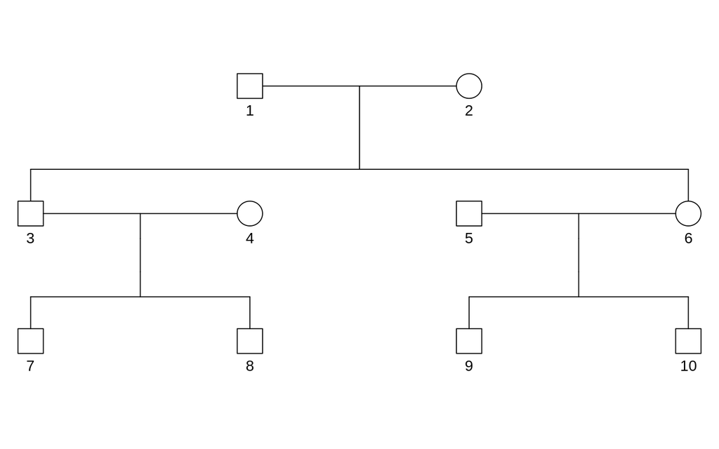

Suppose that the above is family $i$ for which we observe $Y_{i1},\dots Y_{i10} \in \{0, 1\}$.

Circles are females and squares are male.

## Obsessive-compulsive Disorder Study

Mahjani et al. (2020) look at direct genetic effects and maternal effects on OCD

controlling for sex and age of the mother.

## Research Questions

Want to estimate unobserved genetic effects, environmental effects, paternal effects, etc. for binary outcomes.

E.g. pre-eclamptic events, melanoma onset, preterm birth, and autism spectrum disorder. (Pawitan et al. 2004; Lindström et al. 2006; Svensson et al. 2009; Yip et al. 2018; Bai et al. 2019).

## Liability-Threshold Models

$$Y_{ij} = \begin{cases}
1 & \vec x_{ij}^\top\vec\beta + \epsilon_{ij} > 0 \\
0 & \text{otherwise}
\end{cases}$$

where $\epsilon_{ij}$ is standard normally distributed.

There is a latent score $x_{ij}^\top\vec\beta + \epsilon_{ij}$ and we observe $Y_{ij} = 1$ if this exceeds the threshold zero.

A GLM. $\Phi$ is the standard normal CDF.

This choice allows us to use fast methods later.

## Liability-Threshold Models

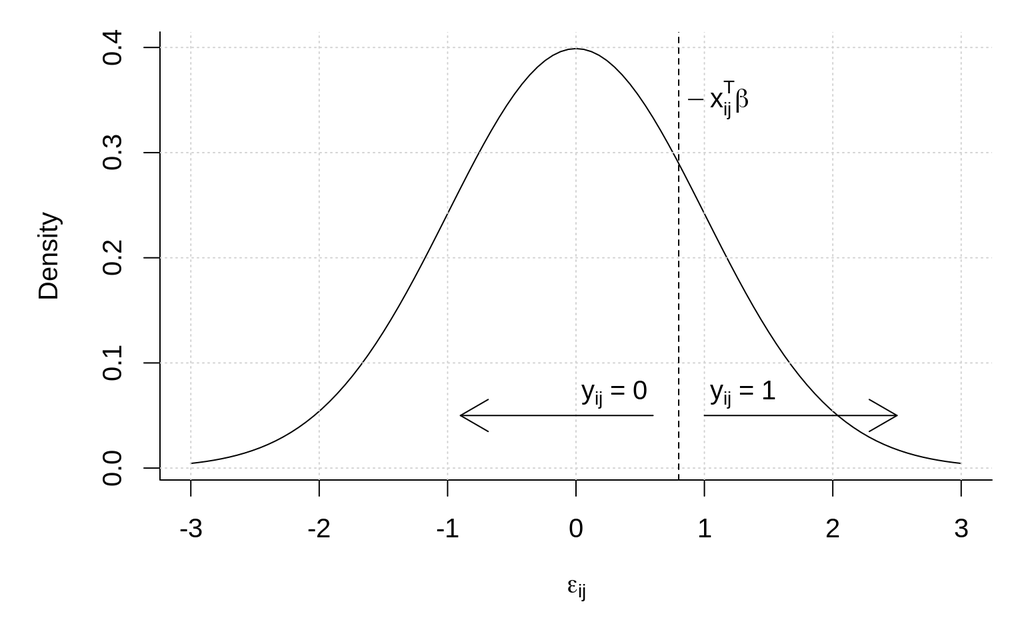

## Example

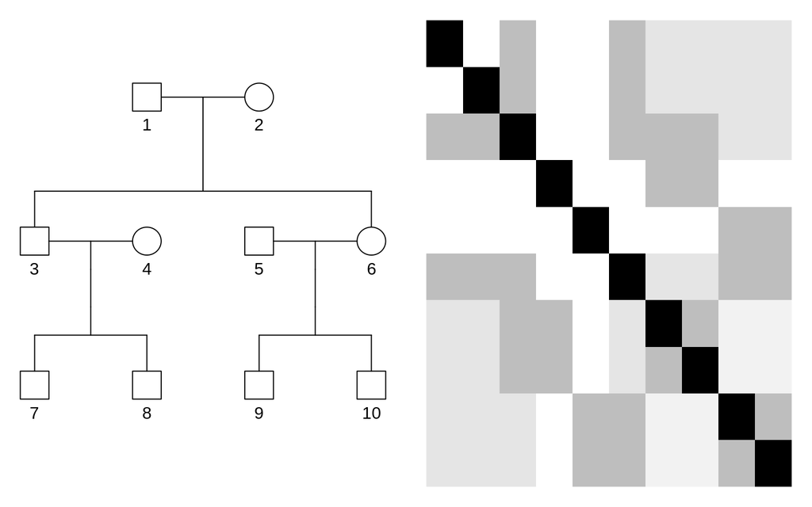

Left the family. Right the kinship matrix.

Darker colors are further from zero.

## Adding Additive Genetic Effects

$g_{ij}$ is the additive genetic effect for individual $j$ in family $i$ and $\mat K_i$ be the kinship matrix of family $i$. Suppose that

$$(g_{i1},\dots,g_{i10})^\top \sim N^{(10)}(\vec 0, \sigma_g^2 \underbrace{2\mat K_i}_{\mat C_{ig}}).$$

Write the model as

$$\begin{align*}
Y_{ij} &= \begin{cases}
1 & \vec x_{ij}^\top\vec\beta + \epsilon_{ij} + g_{ij} > 0 \\
0 & \text{otherwise}
\end{cases}
\end{align*}$$

## ACE Model

Wants to account for environmental effects also: the ACE model.

- Additive genetic effect (A),
- shared environmental factors (C), and
- individual specific effects and measurement errors (E).

The environmental effects (C) are often based on strong assumptions.

## Example (continued)

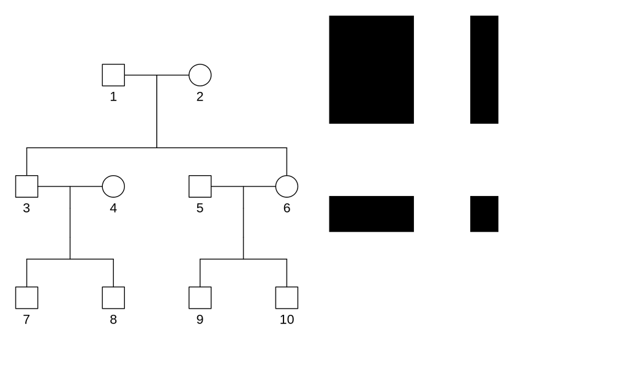

Scale matrix for the environmental effect.

1, 2, 3, and 6 share an environment.

## Example (continued)

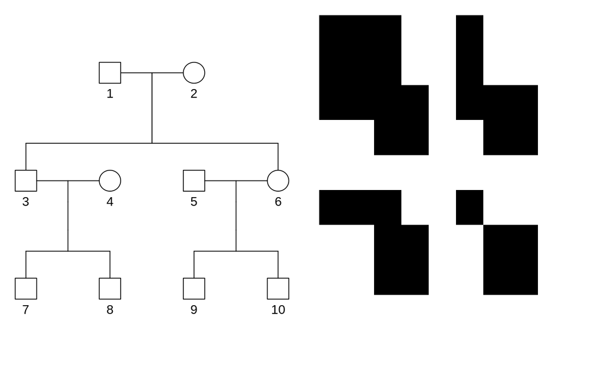

Scale matrix for the environmental effect.

3, 4, 7, and 8 share an environment.

## Example (continued)

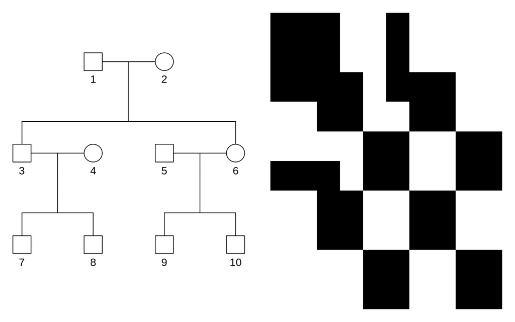

Scale matrix for the environmental effect.

5, 6, 9, and 10 share an environment.

## Adding Environmental Effects

Define $\mat C_{ie}$ as in the previous slide and let:

$$(e_{i1},\dots,e_{i10})^\top \sim N^{(10)}(\vec 0, \sigma_e^2 \mat C_{ie}).$$

The ACE model is:

$$\begin{align*}
Y_{ij} &= \begin{cases}
1 & \vec x_{ij}^\top\vec\beta + \epsilon_{ij} + g_{ij} + e_{ij} > 0 \\
0 & \text{otherwise}
\end{cases} \\
\epsilon_{ij} &\sim N(0, 1) \\
(g_{i1}, \dots, g_{in_i})^\top &
\sim N^{(n_i)}(\vec 0; \sigma_g^2 \mat C_{ig}) \\
(e_{i1}, \dots, e_{in_i})^\top &
\sim N^{(n_i)}(\vec 0; \sigma_e^2 \mat C_{ie}). \\
\end{align*}$$

with $\mat C_{ig}$ being two times the kinship matrix and $\mat C_{ie}$ is a matrix as defined before.

## Inference

Interested in $\sigma_g^2/(1 + \sigma_g^2+ \sigma_e^2)$

the proportion of the variance explained by additive genetic effects,

and $\sigma_e^2/(1 + \sigma_g^2+ \sigma_e^2)$

the proportion of the variance explained by environmental effects.

## Re-write

The model can be written as:

$$\begin{align*}
Y_{ij} &= \begin{cases}
1 & \vec x_{ij}^\top\vec\beta + \epsilon_{ij} > 0 \\
0 & \text{otherwise}
\end{cases} \\
(\epsilon_{i1}, \dots, \epsilon_{in_i})^\top &
\sim N^{(n_i)}(\vec 0; \mat I_{n_i} + \sigma_g^2 \mat C_{ig}
+ \sigma_e^2 \mat C_{ie}).
\end{align*}$$

## Arbitrary Number of Effects

May want paternal effect or maternal effect.

May want other definitions of environments.

E.g. shared adult environment or shared childhood environment.

Can easily extend.

## Re-write (continued)

For $K$ different effects:

$$\begin{align*}
Y_{ij} &= \begin{cases}
1 & \vec x_{ij}^\top\vec\beta + \epsilon_{ij} > 0 \\
0 & \text{otherwise}
\end{cases} \\
(\epsilon_{i1}, \dots, \epsilon_{in_i})^\top &
\sim N^{(n_i)}(\vec 0; \mat I_{n_i} +
\mat\Sigma(\vec\sigma)) \\
\mat\Sigma(\vec\sigma) &= \sum_{k = 1}^K\sigma_k^2 \mat L_{ik}
\end{align*}$$

Given researcher defined $\mat L_{i1}\dots\mat L_{iK}$.

## Estimation

The likelihood has no simple (closed form) expression

… but can expressed as integrals that have been extensively studied.

Used by Pawitan et al. (2004), Lindström et al. (2006), Svensson et al. (2009), Yip et al. (2018), and Bai et al. (2019).

## Previous Work

Previous work only use a likelihood approximation without gradients.

Have to use derivative-free optimization. This is slow.

To simplify the computation, they do not use all data by

- using discretized covariates,
- omitting observations,
- ignoring information from the pedigree, and
- using a composite likelihood like procedure

where individuals with cousin both on their mother and father side is repeated twice.

## New Method and Implementation

Goal: faster estimation method such that we can use all (or almost all) data.

Method with gradient approximations.

A faster approximation and implementation that supports computation in parallel.

Works for an arbitrary number of effects, $K$.

The implementation is in the pedmod package.

## MCMC

Markov chain Monte Carlo (MCMC) is another option.

A way of sequentially sampling from the posterior.

Seems popular with animal data.

See e.g. MCMCglmm (Hadfield 2010) and BLUPF90 (Vitezica 2018).

Very slow!

Fitting a single model took weeks for Mahjani et al. (2020).

# Marginal Likelihood

## Overview

Show the marginal likelihood.

At a high level, mention what have done before and how we extended it.

## Maximum Likelihood

Find the MLE:

$$\argmax_{\vec\beta,\vec\sigma} \sum_{i = 1}^m\log
L_i(\vec\beta,\vec\sigma)$$

where $L_i$ is the marginal likelihood of family (cluster) $i$.

## The Marginal Likelihood

$$\begin{align*}
L_i(\vec\beta,\vec\sigma) &=
\Phi^{(n_i)}(\mat U_i\mat X_i\vec\beta;\vec 0, \mat I +
\mat U_i\mat\Sigma_i(\vec\sigma) \mat U_i) \\
u_{ij} &= 2y_{ij} - 1 \\
\mat U_i &= \text{diag}(\vec u_i) \\
\end{align*}$$

where $\Phi^{(K)}(\vec x; \vec\omega, \mat \Omega)$ is the $K$ dimensional multivariate normal distribution’s CDF with mean $\vec\omega$ and covariance matrix $\mat\Omega$ evaluated at $\vec x$.

Point: need CDF approximation.

## Importance Sampling

Genz (1992) and Genz and Bretz (2002) develop an efficient importance sampling procedure for the CDF with:

1. A heuristic variable re-ordering.
2. Randomized Korobov rules (randomized quasi-Monte Carlo; see Niederreiter 1972; Keast 1973; Cranley and Patterson 1976).

## New Code

Rewritten most of the Fortran code by Genz and Bretz (2002) in C++.

Used in the mvtnorm package (Genz et al. 2020).

Added fast $\Phi$ and $\Phi^{-1}$ approximations.

Added support for computation in parallel.

Seems compute-bound.

Added gradient approximations.

Like Hajivassiliou, McFadden, and Ruud (1996) but with all of the above, re-ordering, and randomized Korobov rules.

# Simulation and Applied Examples

## Overview

Show a simulation study looking at bias and computation time.

Show a procedure to greatly simplify the computational problem while only ignoring very little of the information.

Show some preliminary results.

## Simulation Study

250 families, with 10 members in each family, and the same pedigree. We add an additive genetic effect.

Same pedigree as earlier.

$$\begin{align*}
Y_{ij} &= \begin{cases}
1 & \beta_0 + \beta_1X_{ij} + \beta_2 B_{ij} + \epsilon_{ij} > 0 \\
0 & \text{otherwise}
\end{cases} \\
(\epsilon_{i1}, \dots, \epsilon_{i10})^\top &\sim
N^{(10)}(\vec 0, \mat I_{10} + \sigma_g^2\mat C_{ig})
\end{align*}$$

$X_{ij}\sim N(0, 1)$, $B_{ij}\sim \text{Bin}(0.5, 1)$ are observed.

Compare with MCMCglmm.

Caveat: we use four threads with our method.

## Simulation Study Results

|  | $\beta_0$ | $\beta_1$ | $\beta_2$ | $\sigma_g$ | Time |
| --- | --- | --- | --- | --- | --- |
| Bias | -0.481 | 0.108 | -0.13 | -0.346 | 13.9 |
| Bias / SE | -0.875 | 0.337 | -0.22 | -0.514 |  |

Bias estimates estimated using 100 data sets. The bias estimates are multiplied by 100. The last column shows the average estimation time in seconds. The standard error for the latter is 0.549. The last row shows the bias estimates divided by the standard errors.

## Results: Comparison with MCMC

|  | $\beta_0$ | $\beta_1$ | $\beta_2$ | $\sigma_g$ | Time |
| --- | --- | --- | --- | --- | --- |
| MCMC (mean) | -1.13 | 1.318 | -0.108 | 1.811 | 1588.4 |
| Bias / SE | -2.13 | 0.866 | -0.051 | 1.161 |  |
| MCMC (mode) | -2.70 | 2.220 | 1.293 | -1.019 |  |
| Bias / SE | -1.24 | 1.263 | 0.590 | -0.696 |  |
| New method | -1.22 | 1.363 | -0.024 | 0.515 | 13.4 |
| Bias / SE | -2.23 | 0.902 | -0.012 | 0.301 |  |

Bias estimates using 10 data sets. The bias estimates are multiplied by 100. The last column shows average the estimation time in seconds. The “Bias / SE” rows show the bias estimates divided by the standard errors.

## Simplifying the Real Application

Want to avoid the composite likelihood like procedure and use as much information from the pedigree as possible.

Use the Swedish Multi-Generation Registry (Ekbom 2010) like Mahjani et al. (2020) to study OCD.

Most families are small but one is very large with 618.162 members with 167.279 members with observed outcomes.

Want to avoid 167.279 dimensional integration!

## Dependencies as a Graph

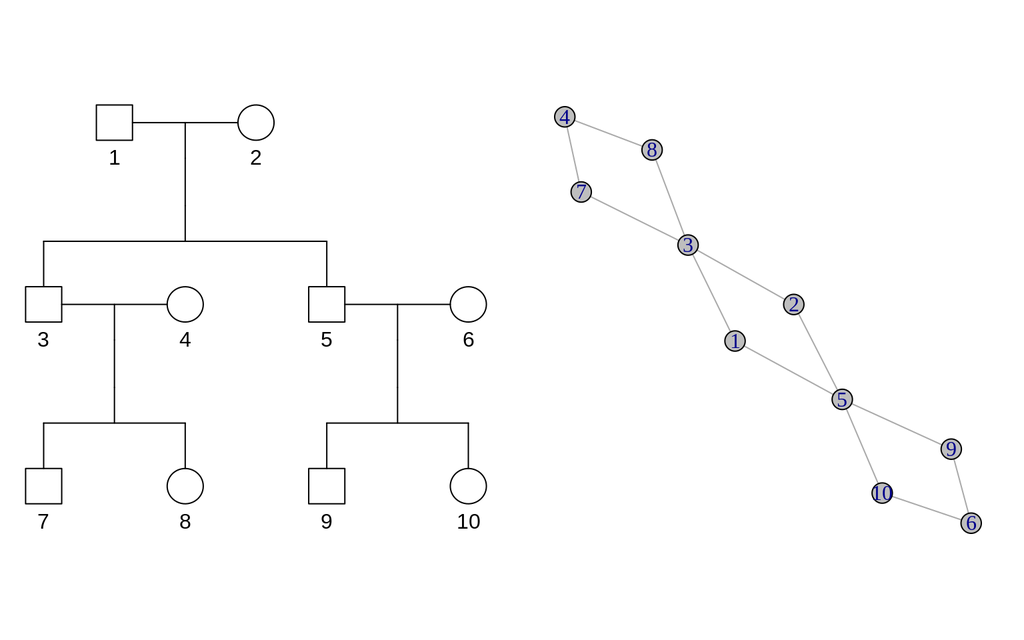

## Dependencies as a Graph (continued)

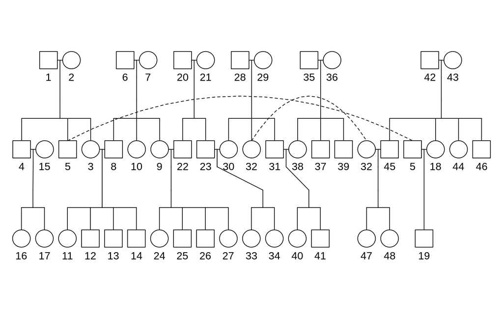

## Dependencies as a Graph (continued)

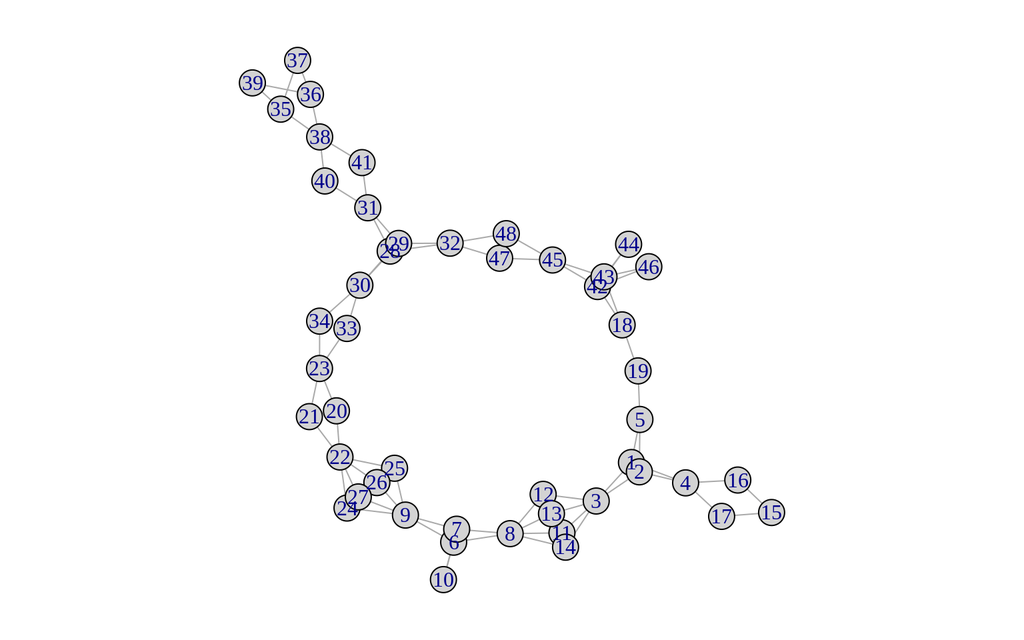

## Cutting the Graph

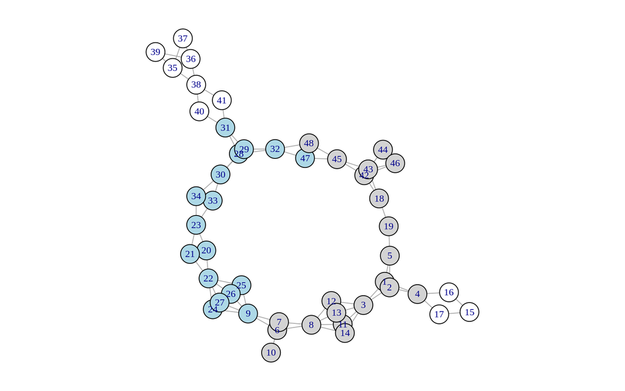

## Reducing the Computational Cost

Removing an edge introduces independence between two individuals

and their ancestor and descendants.

Removing edges can creates two non-connected families (subgraphs) with $\tilde n_k$ and $\tilde n_l$ individuals (vertices)

with $\tilde n_k + \tilde n_l = n_i$.

Yields two integrals to be approximated of size $\tilde n_k$ and $\tilde n_l$

rather than one of size $n$.

## Reducing the Computational Cost

Idea: create $p$ families each of roughly size $n_i / p$ such the number of removed dependencies is minimized.

Essentially the $p$-way partition problem.

Many approximations exists without the connection constraint (Simon and Teng 1997; Karypis and Kumar 1998).

The data can be simplified to at most 200 dimensional integration by removing 3.164 parent-child links

out of 3.944.737 (0.08 percent reduction)!

## Kinship Matrix

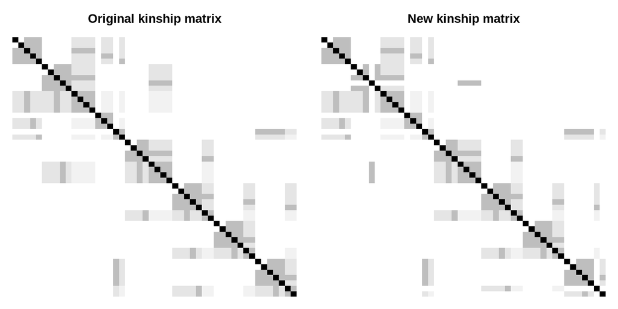

## Profile Likelihood

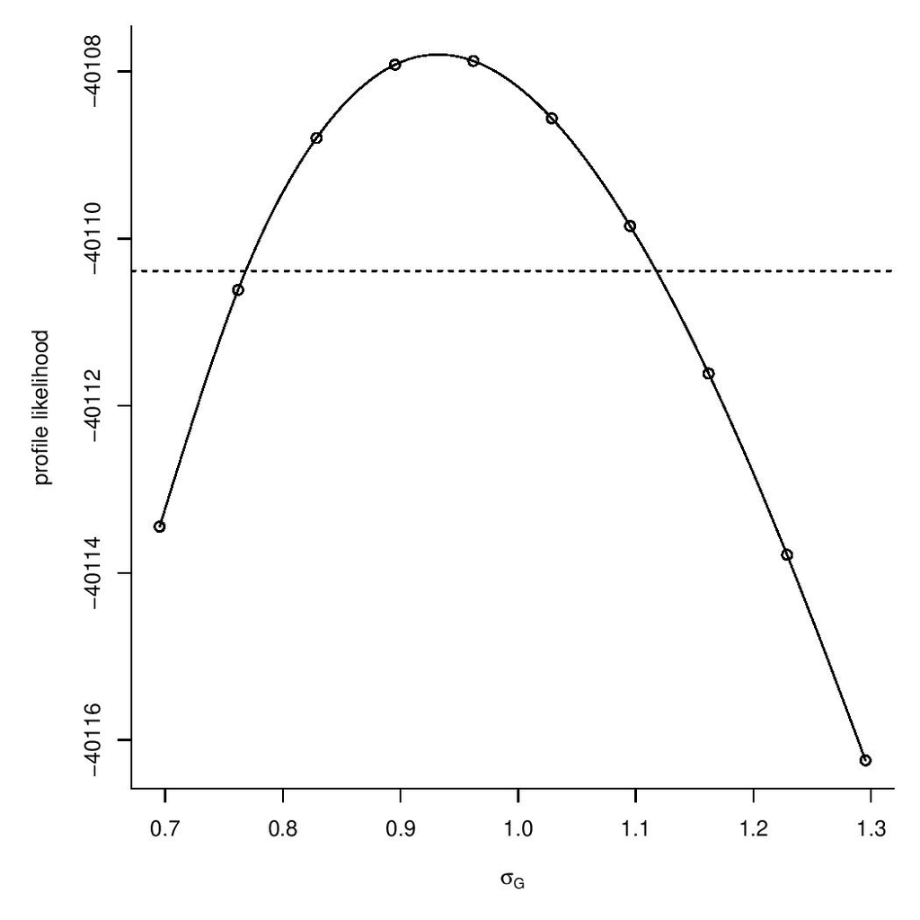

The above profile likelihood was computed in 3 hours and 22 minutes on Vector.

The MCMC analysis in Mahjani et al. (2020) took weeks!

# Extensions

## Improvements

Get better starting values.

Make an efficient Gaussian variational approximation or Laplace approximation to get starting values.

Use stochastic gradient techniques.

Currently, working on a method like suggested by Byrd et al. (2016).

## Survival Data

$Y_{ij}^* \in (0,\infty)$ with independent right censoring time $S_{ij} \in (0,\infty)$.

Only observe $Y_{ij} = \min (Y_{ij}^*, S_{ij})$.

Use a mixed generalized survival model:

$$\begin{align*}
P(Y_{ij}^* > y \mid \epsilon_{ij} = e) &= \Phi(
-\vec g(y)^\top\vec\omega - \vec\beta^\top\vec x_{ij} - e) \\
(\epsilon_{i1}, \dots, \epsilon_{in_i}) &\sim
N^{(n_i)}(\vec 0, \mat\Sigma_i(\vec\theta))
\end{align*}$$

## Survival Data

A simple case is $\vec g(y) = \log y$ in which case

$$\begin{align*}
\omega\log Y_{ij}^* &= -\vec\beta^\top\vec x_{ij} + \epsilon_{ij} \\
\vec\epsilon_i &\sim
N^{(n_i)}(\vec 0, \mat I_{n_i} + \mat\Sigma_i(\vec\sigma))
\end{align*}$$

Or equivalently

$$\begin{align*}
\log Y_{ij}^* &= -\omega^{-1}\vec\beta^\top\vec x_{ij} + \epsilon_{ij} \\
\vec\epsilon_i &\sim
N^{(n_i)}(\vec 0, \omega^{-2}(\mat I_{n_i} + \mat\Sigma_i(\vec\sigma)))
\end{align*}$$

Used in the bivariate case by Szulkin et al. (2017).

Bonus: The CDF dimension is equal to the number of censored individuals.

## Inference in ACE Model

Interested in $\sigma_g^2/(1 + \sigma_g^2+ \sigma_e^2)$

the proportion of the variance **on the log scale** explained by additive genetic effects,

and $\sigma_e^2/(1 + \sigma_g^2+ \sigma_e^2)$

the proportion of the variance **on the log scale** explained by environmental effects.

## Survival Data (continued)

Generally,

$$\begin{align*}
\vec g(Y_{ij}^*)^\top\vec\omega &= -\vec\beta^\top\vec x_{ij} + \epsilon_{ij} \\
\vec\epsilon_i &\sim
N^{(n_i)}(\vec 0, \mat I_{n_i} + \mat\Sigma_i(\vec\sigma))
\end{align*}$$

More flexible.

## Inference in ACE Model

Interested in $\sigma_g^2/(1 + \sigma_g^2+ \sigma_e^2)$

the proportion of the variance **on the** $h(y) = \vec g(y)^\top\vec\omega$ **scale** explained by additive genetic effects,

and $\sigma_e^2/(1 + \sigma_g^2+ \sigma_e^2)$

the proportion of the variance **on the** $h(y) = \vec g(y)^\top\vec\omega$ **scale** explained by environmental effects.

# Other Projects

## Variational Approximations

Recall: I work on variational approximations in biostatistic.

A way of approximating integrals when estimating models. Often very fast.

Used variational approximations for mixed flexible parametric models.

E.g. to account for the hospital being used, repeated measures, environmental effects, dependence between twins, etc.

## Estimating Variational Approximations

Variational approximations easily involves optimization with many parameters.

In the thousands or even a millions.

Implemented generic optimization methods that use the structure of the function being optimized.

Seen ten fold and 100 fold reductions in estimation time. See github.com/boennecd/psqn and github.com/boennecd/psqn-va-ex.

Have seen 20 times faster estimation time compared with a Laplace approximation from `lme4` in some examples and with lower bias.

## Projects Not Mentioned Today

Preliminary work on applying variational approximations for joint survival and marker models.

Has applications e.g. with kidney data to characterise trajectories of biomarkers of kidney function decline while accounting for diabetic complications, glycated hemoglobin (HbA1c) and medications.

## Imputation Method

Improve upon the approximate EM-algorithm by Zhao and Udell (2019) used for imputation of missing values.

See github.com/boennecd/mdgc.

Can provide joint imputation for continuous, binary, ordinal, and multinomial data.

See Christoffersen et al. (2021).

Based on a similar approximation as used for the family data.

# Conclusions

## Conclusions

Extended the estimation method suggested by Pawitan et al. (2004).

Showed that the new C++ implementation is fast

for large data sets with moderate to high dimensional integrals per cluster.

Discussed extensions to other types of outcomes.

# Thank You!

The presentation is at rpubs.com/boennecd/KTH-Pre-Meb-Meeting.

The markdown is at github.com/boennecd/Talks.

The R package is at github.com/boennecd/pedmod.

References are on the next slide.

# References

Bai, Dan, Benjamin Hon Kei Yip, Gayle C. Windham, Andre Sourander, Richard Francis, Rinat Yoffe, Emma Glasson, et al. 2019. “Association of Genetic and Environmental Factors With Autism in a 5-Country Cohort.” *JAMA Psychiatry* 76 (10): 1035–43. https://doi.org/10.1001/jamapsychiatry.2019.1411.

Byrd, R. H., S. L. Hansen, Jorge Nocedal, and Y. Singer. 2016. “A Stochastic Quasi-Newton Method for Large-Scale Optimization.” *SIAM Journal on Optimization* 26 (2): 1008–31. https://doi.org/10.1137/140954362.

Christoffersen, Benjamin, Mark Clements, Keith Humphreys, and Hedvig Kjellström. 2021. “Asymptotically Exact and Fast Gaussian Copula Models for Imputation of Mixed Data Types.” http://arxiv.org/abs/2102.02642.

Cranley, R., and T. N. L. Patterson. 1976. “Randomization of Number Theoretic Methods for Multiple Integration.” *SIAM Journal on Numerical Analysis* 13 (6): 904–14. http://www.jstor.org/stable/2156452.

Ekbom, Anders. 2010. “The Swedish Multi-Generation Register.” In *Methods in Molecular Biology*, 215–20. Humana Press. https://doi.org/10.1007/978-1-59745-423-0_10.

Genz, Alan. 1992. “Numerical Computation of Multivariate Normal Probabilities.” *Journal of Computational and Graphical Statistics* 1 (2): 141–49. http://www.jstor.org/stable/1390838.

Genz, Alan, and Frank Bretz. 2002. “Comparison of Methods for the Computation of Multivariate T Probabilities.” *Journal of Computational and Graphical Statistics* 11 (4): 950–71. https://doi.org/10.1198/106186002394.

Genz, Alan, Frank Bretz, Tetsuhisa Miwa, Xuefei Mi, Friedrich Leisch, Fabian Scheipl, and Torsten Hothorn. 2020. *mvtnorm: Multivariate Normal and T Distributions*. https://CRAN.R-project.org/package=mvtnorm.

Hadfield, Jarrod D. 2010. “MCMC Methods for Multi-Response Generalized Linear Mixed Models: The MCMCglmm R Package.” *Journal of Statistical Software* 33 (2): 1–22. https://www.jstatsoft.org/v33/i02/.

Hajivassiliou, Vassilis, Daniel McFadden, and Paul Ruud. 1996. “Simulation of Multivariate Normal Rectangle Probabilities and Their Derivatives Theoretical and Computational Results.” *Journal of Econometrics* 72 (1): 85–134. https://doi.org/https://doi.org/10.1016/0304-4076(94)01716-6.

Karypis, George, and Vipin Kumar. 1998. “A Fast and High Quality Multilevel Scheme for Partitioning Irregular Graphs.” *SIAM J. Sci. Comput.* 20 (1): 359–92.

Keast, P. 1973. “Optimal Parameters for Multidimensional Integration.” *SIAM Journal on Numerical Analysis* 10 (5): 831–38. https://doi.org/10.1137/0710068.

Lindström, L., Y. Pawitan, M. Reilly, K. Hemminki, P. Lichtenstein, and K. Czene. 2006. “Estimation of Genetic and Environmental Factors for Melanoma Onset Using Population-Based Family Data.” *Statistics in Medicine* 25 (18): 3110–23. https://doi.org/https://doi.org/10.1002/sim.2266.

Mahjani, Behrang, Lambertus Klei, Christina M. Hultman, Henrik Larsson, Bernie Devlin, Joseph D. Buxbaum, Sven Sandin, and Dorothy E. Grice. 2020. “Maternal Effects as Causes of Risk for Obsessive-Compulsive Disorder.” *Biological Psychiatry* 87 (12): 1045–51. https://doi.org/https://doi.org/10.1016/j.biopsych.2020.01.006.

Niederreiter, H. 1972. “On a Number-Theoretical Integration Method.” *Aequationes Mathematicae* 8 (3): 304–11. https://doi.org/10.1007/BF01844507.

Pawitan, Y., M. Reilly, E. Nilsson, S. Cnattingius, and P. Lichtenstein. 2004. “Estimation of Genetic and Environmental Factors for Binary Traits Using Family Data.” *Statistics in Medicine* 23 (3): 449–65. https://doi.org/https://doi.org/10.1002/sim.1603.

Simon, Horst D., and Shang-Hua Teng. 1997. “How Good Is Recursive Bisection?” *SIAM Journal on Scientific Computing* 18 (5): 1436–45. https://doi.org/10.1137/S1064827593255135.

Svensson, Anna C., Sven Sandin, Sven Cnattingius, Marie Reilly, Yudi Pawitan, Christina M. Hultman, and Paul Lichtenstein. 2009. “Maternal Effects for Preterm Birth: A Genetic Epidemiologic Study of 630,000 Families.” *American Journal of Epidemiology* 170 (11): 1365–72. https://doi.org/10.1093/aje/kwp328.

Szulkin, Robert, Mark S. Clements, Patrik K. E. Magnusson, Fredrik E. Wiklund, and Ralf Kuja-Halkola. 2017. “Estimating Heritability of Prostate Cancer-Specific Survival Using Population-Based Registers.” *The Prostate* 77 (8): 900–907. https://doi.org/https://doi.org/10.1002/pros.23344.

Vitezica, Ignacy Misztal AND Shogo Tsuruta AND Daniela Lourenco AND Yutaka Masuda AND Ignacio Aguilar AND Andres Legarra AND Zulma. 2018. *Manual for Blupf90 Family Programs*. University of Georgia. http://nce.ads.uga.edu/wiki/doku.php?id=documentation.

Yip, Benjamin Hon Kei, Dan Bai, Behrang Mahjani, Lambertus Klei, Yudi Pawitan, Christina M Hultman, Dorothy E Grice, et al. 2018. “Heritable Variation, with Little or No Maternal Effect, Accounts for Recurrence Risk to Autism Spectrum Disorder in Sweden.” *Biological Psychiatry* 83 (7): 589–97.

Zhao, Yuxuan, and Madeleine Udell. 2019. “Missing Value Imputation for Mixed Data via Gaussian Copula.” http://arxiv.org/abs/1910.12845.